# numpy基础 | Jia-Du's Blog

## Record something and Do something.

# numpy基础

2020-03-13

Python

# Numpy 学习笔记

## 1. 基础函数

- 创建
- 打印
- 基本操作
- 常用函数
- 下标，切片，迭代
1. numpy array 和 python 序列的差异
   - 创建时固定大小（形状），改变大小相当于删除重建
   - 元素类型相同
   - 比python内建数据类型处理速度更快
   - 被许多更高层次的库所使用（如Tensorflow, Pytorch)
   - 两大基础功能： 向量化(vectorization) ，广播(broadcasting)
2. 为什么numpy效率更高
   - 更简洁的代码
   - 更接近数学符号的表达形式
3. numpy数组： numpy.array
   - 使用Python序列作为参数创建

     可以自动将序列转化为对应维度的numpy数组

     ```
     (Python)
       # 一维
       a = np.array([2,3,4])

       # 二维
       b = np.array([(1.5,2,3), (4,5,6)])

       # array([[1.5, 2. , 3. ],
       #      [4. , 5. , 6. ]])
     ```

     可以指定元素类型

     ```
     (Python)
       c = np.array( [ [1,2], [3,4] ], dtype=complex )
     ```

   - 使用占位符(Placeholder)创建特定形状的numpy数组
     - `numpy.zeros(shape, dtype)`

       用0填充空位

       shape: 需要创建的n维数组的形状，turple类型(元组)

       e.g.,

       ```
       (Python)
       np.zeros((3, 4))

       # array([[0., 0., 0., 0.],
       #         [0., 0., 0., 0.],
       #         [0., 0., 0., 0.]])
       ```

     - `numpy.ones(shape, dtype)`

       用1填充空位
     - `numpy.empty(shape, dtype)`

       随机填充
     - 使用`zeros_like`等函数填充
   - 使用arange(类似range)
   - 使用linsapce（类似range，但是生成的是浮点数）
   - 显示：
     - 最后的轴横向显示
     - 倒数第二的轴上下显示
     - 如有更高维度，也上下显示
     - 中间元素会被省略，如需强制输出可用：`np.set_printoptions(threshold=sys.maxsize)`
   - 使用reshape更改数组的形状
4. 基本运算

   numpy数组的运算方法作用到每一个元素

   作用到每个元素的四则运算：

   `+`, `-`, `*`, `/`

   矩阵乘法：

   `@`
5. 一元操作
   - sum(axis)
   - max(axis)
   - min(axis)
   - cumsum

     一元操作可以通过`axis`参数指定操作的方向
6. 其他操作
   - np.sqrt
   - np.exp
   - np.add
   - ...
7. 下标，切片，迭代
   - 对多维数组的所有元素操作:`flat`属性

     ```
     (Python)
       for element in b.flat:
           print(element)
     ```

8. 形状操作
   - 返回新数组，不改动原数组
     - `ravel`： 返回flatten后的数组
     - `reshape(axis1, axis2, ...)`：返回形状为:（axaxis1, axis2, ...）的数组
     - `T`：返回转置后的数组
   - 修改原始数组:
     - `resize()`

```python
import numpy as np
```

Numpy中的维度被称为轴

一个一维数组有一个轴，二维数组有两个轴，依此类推。

```python
a = np.arange(15).reshape(3, 5)
print(a.shape, a.ndim, a.itemsize, a.size)
type(a)
```

```
(3, 5) 2 4 15
```

```
numpy.ndarray
```

```python
a = [[ 0,  1,  2,  3],
       [10, 11, 12, 13],
       [20, 21, 22, 23],
       [30, 31, 32, 33],
       [40, 41, 42, 43]]
a = np.array(a)

b = np.array([[ 0,  1,  2],
       [10, 11, 12],
       [20, 21, 22],
       [30, 31, 32],
       [40, 41, 42]])

print('A:',a)
print('B:', b)
# print('Vstack: ', np.vstack((a,b)))
print('HStack:', np.hstack((a,b)))
print('ColStack:', np.column_stack((a,b)))
```

```
A: [[ 0  1  2  3]
 [10 11 12 13]
 [20 21 22 23]
 [30 31 32 33]
 [40 41 42 43]]
B: [[ 0  1  2]
 [10 11 12]
 [20 21 22]
 [30 31 32]
 [40 41 42]]
HStack: [[ 0  1  2  3  0  1  2]
 [10 11 12 13 10 11 12]
 [20 21 22 23 20 21 22]
 [30 31 32 33 30 31 32]
 [40 41 42 43 40 41 42]]
ColStack: [[ 0  1  2  3  0  1  2]
 [10 11 12 13 10 11 12]
 [20 21 22 23 20 21 22]
 [30 31 32 33 30 31 32]
 [40 41 42 43 40 41 42]]
```

```python
from numpy import newaxis
```

Stack:

将两个数组按行或者按列拼接起来（堆叠）（形状相同）

- vstack
- hstack
- column_stack
- row_stack

在任何情况下`vstack = row_stack`

在1维或者2维情况下：`hstack = column_stack`

In general, for arrays with more than two dimensions, hstack stacks along their second axes, vstack stacks along their first axes, and concatenate allows for an optional arguments giving the number of the axis along which the concatenation should happen.

**切分数组为几个更小的数组**

```python
a = np.array([[6., 7., 6., 9., 0., 5., 4., 0., 6., 8., 5., 2.],
       [8., 5., 5., 7., 1., 8., 6., 7., 1., 8., 1., 0.]])
```

```python
np.hsplit(a, 3)
```

```
[array([[6., 7., 6., 9.],
        [8., 5., 5., 7.]]), array([[0., 5., 4., 0.],
        [1., 8., 6., 7.]]), array([[6., 8., 5., 2.],
        [1., 8., 1., 0.]])]
```

```python
np.hsplit(a, (3,4))
```

```
[array([[6., 7., 6.],
        [8., 5., 5.]]), array([[9.],
        [7.]]), array([[0., 5., 4., 0., 6., 8., 5., 2.],
        [1., 8., 6., 7., 1., 8., 1., 0.]])]
```

**数组复制**

常规赋值是浅复制,相当于复制了指针

函数传参也是浅复制

```python
a = np.array([[6., 7., 6., 9., 0., 5., 4., 0., 6., 8., 5., 2.],
       [8., 5., 5., 7., 1., 8., 6., 7., 1., 8., 1., 0.]])
b = a

print(b is a)
print(a)
print(b)
a.resize((4,6))
print(a)
print(b)
```

[output not shown]

**使用view方法创建一个新的数组，可以共享相同的数据**

- 如果直接更改数据内容，源数组同步改变
- 修改形状不影响原始数据
- 直接赋值影响原始数据
- 切片操作返回的是一个view产生的对象

```python
c = a.view()

print(c is a)
print(c.base is a)
```

```
False
True
```

```python
c.flags.owndata
```

```
False
```

```python
a = np.array([[6., 7., 6., 9., 0., 5., 4., 0., 6., 8., 5., 2.],
       [8., 5., 5., 7., 1., 8., 6., 7., 1., 8., 1., 0.]])
c = a.view()
c = c.reshape((4,6))
print(c.shape, a.shape)
c.resize(4,6)
print(c.shape, a.shape)
```

```
(4, 6) (2, 12)
(4, 6) (2, 12)
```

**深度复制**

- copy

如果在切片之后不需要中间数据了，可以直接使用copy进行深度复制，然后再内存中直接删除中间数据

```python
a = np.arange(int(1e8))
b = a[:100].copy()
del a  # the memory of ``a`` can be released.
print(b)
```

```
[ 0  1  2  3  4  5  6  7  8  9 10 11 12 13 14 15 16 17 18 19 20 21 22 23
 24 25 26 27 28 29 30 31 32 33 34 35 36 37 38 39 40 41 42 43 44 45 46 47
 48 49 50 51 52 53 54 55 56 57 58 59 60 61 62 63 64 65 66 67 68 69 70 71
 72 73 74 75 76 77 78 79 80 81 82 83 84 85 86 87 88 89 90 91 92 93 94 95
 96 97 98 99]
```

Here is a list of some useful NumPy functions and methods names ordered in categories. See Routines for the full list.

**Array Creation**

arange, array, copy, empty, empty_like, eye, fromfile, fromfunction, identity, linspace, logspace, mgrid, ogrid, ones, ones_like, r_, zeros, zeros_like

**Conversions**

ndarray.astype, atleast_1d, atleast_2d, atleast_3d, mat

**Manipulations**

array_split, column_stack, concatenate, diagonal, dsplit, dstack, hsplit, hstack, ndarray.item, newaxis, ravel, repeat, reshape, resize, squeeze, swapaxes, take, transpose, vsplit, vstack

**Questions**

all, any, nonzero, where

**Ordering**

argmax, argmin, argsort, max, min, ptp, searchsorted, sort

**Operations**

choose, compress, cumprod, cumsum, inner, ndarray.fill, imag, prod, put, putmask, real, sum

**Basic Statistics**

cov, mean, std, var

**Basic Linear Algebra**

cross, dot, outer, linalg.svd, vdot

## 深入理解

- 广播机制(broadcasting rules)
- 高级索引机制及技巧

**广播机制**

允许普通函数处理形状不同的参数

- 如果输入的数组形状不同，在形状最小的数组的维度+1，直到所有数组的形状都相同
- 一个数组在特定维度的大小为1，则当作它在这个维度有最大维度来处理
- 应用广播规则之后，所有数组的形状都应该一致

**高级索引-整数索引数组**

- numpy数组不仅可以通过常规的索引方法访问，还可以通过证书数组或者布尔数组来索引
- 如果用一个1维数组索引一个多维数组，默认多维数组的第一个维度
- 如果用多维数组索引多维数组，二者必须具有相同形状
- a[i,j] = a[(i.j)]
- 可以借助 argmax使用
- 可以用来赋值
- 如果索引数列中有重复元素，则操作也重复，最终结果以最后一次操作为准

```python
a = np.arange(12)**2
i = np.array([1, 1, 3, 8, 5])
print(a)
print(a[i])
```

```
[  0   1   4   9  16  25  36  49  64  81 100 121]
[ 1  1  9 64 25]
```

**高级索引-布尔值索引**

- 对每个位置的元素进行选取：形状需要和目标数组完全一致，True表示需要该位置元素，False表示i不需要该位置的元素(返回一个选中的元素的列表-1维）
- 生成Mandelbort set的图片
- 选取某个维度的数据

```python
a = np.arange(12).reshape(3,4)
b = a > 4
print(b)
print(a[b])
```

```
[[False False False False]
 [False  True  True  True]
 [ True  True  True  True]]
[ 5  6  7  8  9 10 11]
```

[figure not shown]

```python
import matplotlib.pyplot as plt
import numpy as np

def mandelbrot( h,w, maxit=20 ):
    y,x = np.ogrid[ -1.4:1.4:h*1j, -2:0.8:w*1j ]
    c = x+y*1j
    z = c
    divtime = maxit + np.zeros(z.shape, dtype=int)

    for i in range(maxit):
        z = z**2 + c
        diverge = z*np.conj(z) > 2**2            # who is diverging
        div_now = diverge & (divtime==maxit)  # who is diverging now
        divtime[div_now] = i                  # note when
        z[diverge] = 2                        # avoid diverging too much

    return divtime

plt.imshow(mandelbrot(400,400))
```

**ix_(): 组合不同的向量,对数组的每个元素进行操作**

使用ix_()函数组合不同的向量，使得所有向量能够直接进行运算。

```python
a = np.array([2,3,4,5])
b = np.array([8,5,4])
c = np.array([5,4,6,8,3])
ax,bx,cx = np.ix_(a,b,c)
print(ax.shape, bx.shape, cx.shape)
result = ax+bx*cx
print(result)
result = ax+bx+cx
print(result)
print(ax*bx*cx)
```

```
(4, 1, 1) (1, 3, 1) (1, 1, 5)
[[[42 34 50 66 26]
  [27 22 32 42 17]
  [22 18 26 34 14]]

 [[43 35 51 67 27]
  [28 23 33 43 18]
  [23 19 27 35 15]]

 [[44 36 52 68 28]
  [29 24 34 44 19]
  [24 20 28 36 16]]

 [[45 37 53 69 29]
  [30 25 35 45 20]
  [25 21 29 37 17]]]
[[[15 14 16 18 13]
  [12 11 13 15 10]
  [11 10 12 14  9]]

 [[16 15 17 19 14]
  [13 12 14 16 11]
  [12 11 13 15 10]]

 [[17 16 18 20 15]
  [14 13 15 17 12]
  [13 12 14 16 11]]

 [[18 17 19 21 16]
  [15 14 16 18 13]
  [14 13 15 17 12]]]
[[[ 80  64  96 128  48]
  [ 50  40  60  80  30]
  [ 40  32  48  64  24]]

 [[120  96 144 192  72]
  [ 75  60  90 120  45]
  [ 60  48  72  96  36]]

 [[160 128 192 256  96]
  [100  80 120 160  60]
  [ 80  64  96 128  48]]

 [[200 160 240 320 120]
  [125 100 150 200  75]
  [100  80 120 160  60]]]
```

## 基本数组操作

- np.tanspose() 转置
- np.linalg.inv() 求逆矩阵
- np.eye(dimention) 单位矩阵
- `@` 矩阵乘法：`j @ j`
- np.trace 对角线元素求和(矩阵的迹）
- np.linalg.solve(a, b) 求解线性矩阵方程AX=B，返回X
- np.linalg.eig(j) 求j的特征向量
- np.linalg.dot 两个数组的点积
- np.linalg.vdot 两个向量的点积
- np.linalg.inner 俩ing个数组的内积
- np.linalg.matmul 两个数组的矩阵积
- np.linalg.determinant 数组的行列式

## 直方图 Histograms

- numpy.histgram()： 生成直方图的数据（每个方块的高度）
- matplotlib.plot.hist() 自动画出直方图

```
n
 [0.00118758 0.         0.         0.         0.         0.00118758
 0.00237515 0.00593788 0.0047503  0.00950061 0.01662606 0.0344397
 0.04987819 0.0593788  0.0890682  0.10806942 0.13775882 0.2030755
 0.26126673 0.37883675 0.46671738 0.47978072 0.56528619 0.6294153
 0.71017047 0.78736291 0.82892807 0.82417777 0.73392199 0.72085865
 0.67691834 0.59616317 0.55578558 0.46790496 0.36933615 0.3218331
 0.20782581 0.18051156 0.12350791 0.0843179  0.06650426 0.04037759
 0.01900122 0.01900122 0.01781364 0.01187576 0.00356273 0.00118758
 0.         0.00237515]
bins
 [-0.28356776 -0.19936262 -0.11515749 -0.03095235  0.05325278  0.13745792
  0.22166305  0.30586819  0.39007332  0.47427846  0.55848359  0.64268873
  0.72689386  0.811099    0.89530413  0.97950927  1.0637144   1.14791954
  1.23212467  1.31632981  1.40053494  1.48474008  1.56894521  1.65315035
  1.73735548  1.82156062  1.90576575  1.98997089  2.07417602  2.15838116
  2.24258629  2.32679143  2.41099656  2.4952017   2.57940683  2.66361197
  2.7478171   2.83202224  2.91622737  3.00043251  3.08463764  3.16884278
  3.25304791  3.33725305  3.42145818  3.50566332  3.58986845  3.67407359
  3.75827872  3.84248386  3.92668899]
```

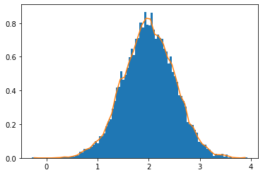

```python
import numpy as np

mu, sigma = 2,0.5
v = np.random.normal(mu, sigma, 10000)

plt.hist(v, bins=100, density=1)

(n, bins) = np.histogram(v, bins=50, density=True)

print('n\n', n)
print('bins\n', bins)

plt.plot(.5*(bins[1:]+bins[:-1]), n)
```